← Probabilistic Machine Learning

# Gaussian Discriminant Analysis

## Real-World Scenario: Cancer Subtype Classification from Blood Biomarkers

Each subtype has a different biomarker distribution. We'll build a **generative classifier** by modeling the class-conditional densities $p(\mathbf{x} | y = c)$ as multivariate Gaussians and using Bayes' rule to compute the posterior $p(y = c | \mathbf{x})$. Depending on whether we allow each class its own covariance matrix or force a shared covariance, we get **quadratic** (QDA) or **linear** (LDA) decision boundaries.

```python
import numpy as np
import matplotlib.pyplot as plt
import matplotlib as mpl
from scipy.stats import multivariate_normal
from matplotlib.colors import ListedColormap

np.random.seed(42)
plt.style.use('seaborn-v0_8-whitegrid')
mpl.rcParams['font.family'] = 'DejaVu Sans'
```

## Key Formulas from PML Chapter 9.2

**Generative classifier** (Eq. 9.1 — Bayes' rule for classification):

$$p(y = c | \mathbf{x}, \boldsymbol{\theta}) = \frac{p(\mathbf{x} | y = c, \boldsymbol{\theta})\, p(y = c | \boldsymbol{\theta})}{\sum_{c'} p(\mathbf{x} | y = c', \boldsymbol{\theta})\, p(y = c' | \boldsymbol{\theta})}$$

**Gaussian class-conditional density** (Eq. 9.2):

$$p(\mathbf{x} | y = c, \boldsymbol{\theta}) = \mathcal{N}(\mathbf{x} | \boldsymbol{\mu}_c, \boldsymbol{\Sigma}_c)$$

**Log-posterior / discriminant function** (Eq. 9.4):

$$\log p(y = c | \mathbf{x}, \boldsymbol{\theta}) = \log \pi_c - \frac{1}{2} \log |2\pi \boldsymbol{\Sigma}_c| - \frac{1}{2}(\mathbf{x} - \boldsymbol{\mu}_c)^\top \boldsymbol{\Sigma}_c^{-1}(\mathbf{x} - \boldsymbol{\mu}_c) + \text{const}$$

**With tied covariances** $\boldsymbol{\Sigma}_c = \boldsymbol{\Sigma}$, the discriminant simplifies to a linear function (Eq. 9.7):

$$\log p(y = c | \mathbf{x}, \boldsymbol{\theta}) = \gamma_c + \mathbf{x}^\top \boldsymbol{\beta}_c + \kappa$$

where $\boldsymbol{\beta}_c = \boldsymbol{\Sigma}^{-1} \boldsymbol{\mu}_c$ and $\gamma_c = \log \pi_c - \frac{1}{2} \boldsymbol{\mu}_c^\top \boldsymbol{\Sigma}^{-1} \boldsymbol{\mu}_c$.

## 1. Generate Synthetic Biomarker Data

We create realistic 2D data for three NSCLC subtypes. Each subtype has its own mean biomarker profile and covariance structure (reflecting different biomarker correlations).

```python
# True parameters for each cancer subtype
# Feature 1: CEA (ng/mL, log-transformed)
# Feature 2: CYFRA 21-1 (ng/mL, log-transformed)

class_names = ['Adenocarcinoma', 'Squamous Cell', 'Large Cell']
colors = ['#2196F3', '#F44336', '#4CAF50']  # Blue, Red, Green

# Adenocarcinoma: high CEA, moderate CYFRA, positive correlation
mu1 = np.array([3.5, 1.0])
Sigma1 = np.array([[1.2, 0.4],
                   [0.4, 0.8]])

# Squamous Cell: moderate CEA, high CYFRA, negative correlation
mu2 = np.array([0.5, 4.0])
Sigma2 = np.array([[0.8, -0.3],
                   [-0.3, 1.5]])

# Large Cell: intermediate, nearly spherical
mu3 = np.array([-2.0, 0.5])
Sigma3 = np.array([[1.0, 0.1],
                   [0.1, 0.6]])

# Class priors (prevalence in clinic)
true_pi = np.array([0.45, 0.35, 0.20])  # Adeno most common

# Generate samples
N = 300
n1 = int(N * true_pi[0])
n2 = int(N * true_pi[1])
n3 = N - n1 - n2

X1 = np.random.multivariate_normal(mu1, Sigma1, n1)
X2 = np.random.multivariate_normal(mu2, Sigma2, n2)
X3 = np.random.multivariate_normal(mu3, Sigma3, n3)

X = np.vstack([X1, X2, X3])
y = np.concatenate([np.zeros(n1), np.ones(n2), 2*np.ones(n3)]).astype(int)

true_mus = [mu1, mu2, mu3]
true_Sigmas = [Sigma1, Sigma2, Sigma3]

print(f"Generated {N} patient samples:")
for c in range(3):
    print(f"  {class_names[c]:20s}: {(y == c).sum()} samples ({(y == c).mean():.0%})")
```

```
Generated 300 patient samples:
  Adenocarcinoma      : 135 samples (45%)
  Squamous Cell       : 105 samples (35%)
  Large Cell          : 60 samples (20%)
```

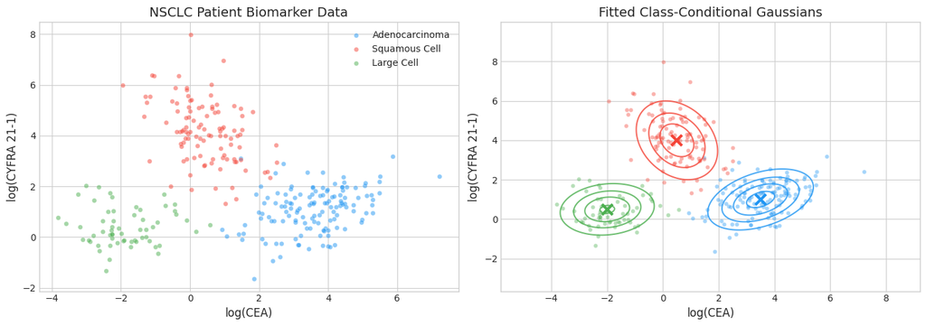

```python
# Visualize the data
fig, axes = plt.subplots(1, 2, figsize=(14, 5))

# Left: raw data with class labels
for c in range(3):
    mask = y == c
    axes[0].scatter(X[mask, 0], X[mask, 1], c=colors[c], alpha=0.5, s=25,
                    label=class_names[c], edgecolors='white', linewidths=0.3)
axes[0].set_xlabel('log(CEA)', fontsize=12)
axes[0].set_ylabel('log(CYFRA 21-1)', fontsize=12)
axes[0].set_title('NSCLC Patient Biomarker Data', fontsize=14)
axes[0].legend(fontsize=10)

# Right: data with fitted Gaussians (true parameters)
for c in range(3):
    mask = y == c
    axes[1].scatter(X[mask, 0], X[mask, 1], c=colors[c], alpha=0.4, s=20,
                    edgecolors='white', linewidths=0.3)

# Draw contours of class-conditional Gaussians
x_min, x_max = X[:, 0].min() - 2, X[:, 0].max() + 2
y_min, y_max = X[:, 1].min() - 2, X[:, 1].max() + 2
xx, yy = np.meshgrid(np.linspace(x_min, x_max, 200),
                     np.linspace(y_min, y_max, 200))
grid = np.column_stack([xx.ravel(), yy.ravel()])

for c, (mu, Sigma, color) in enumerate(zip(true_mus, true_Sigmas, colors)):
    rv = multivariate_normal(mu, Sigma)
    zz = rv.pdf(grid).reshape(xx.shape)
    axes[1].contour(xx, yy, zz, levels=4, colors=[color], alpha=0.8, linewidths=1.5)
    axes[1].plot(*mu, 'x', color=color, markersize=12, markeredgewidth=3)

axes[1].set_xlabel('log(CEA)', fontsize=12)
axes[1].set_ylabel('log(CYFRA 21-1)', fontsize=12)
axes[1].set_title('Fitted Class-Conditional Gaussians', fontsize=14)

plt.tight_layout()
plt.show()
```

## 2. Model Fitting via Maximum Likelihood (Section 9.2.4)

The log-likelihood of the GDA model is (Eq. 9.18):

$$\log p(\mathcal{D}|\boldsymbol{\theta}) = \left[\sum_{n=1}^{N} \sum_{c=1}^{C} \mathbb{1}(y_n = c) \log \pi_c\right] + \sum_{c=1}^{C} \left[\sum_{n: y_n = c} \log \mathcal{N}(\mathbf{x}_n | \boldsymbol{\mu}_c, \boldsymbol{\Sigma}_c)\right]$$

The MLE estimates are (Eqs. 9.19–9.20):

$$\hat{\pi}_c = \frac{N_c}{N}, \quad \hat{\boldsymbol{\mu}}_c = \frac{1}{N_c} \sum_{n: y_n = c} \mathbf{x}_n, \quad \hat{\boldsymbol{\Sigma}}_c = \frac{1}{N_c} \sum_{n: y_n = c} (\mathbf{x}_n - \hat{\boldsymbol{\mu}}_c)(\mathbf{x}_n - \hat{\boldsymbol{\mu}}_c)^\top$$

```python
def fit_gda(X, y, C):
    """
    Fit GDA model via MLE (Eqs. 9.19-9.20).

    Returns class priors, means, and per-class covariances.
    """
    N = len(y)
    pi_hat = np.zeros(C)
    mu_hat = []
    Sigma_hat = []

    for c in range(C):
        mask = y == c
        Nc = mask.sum()

        # Class prior: pi_c = N_c / N
        pi_hat[c] = Nc / N

        # Class mean: mu_c = (1/N_c) * sum of x_n for y_n = c
        mu_c = X[mask].mean(axis=0)
        mu_hat.append(mu_c)

        # Class covariance: Sigma_c = (1/N_c) * sum of (x_n - mu_c)(x_n - mu_c)^T
        diff = X[mask] - mu_c
        Sigma_c = (diff.T @ diff) / Nc
        Sigma_hat.append(Sigma_c)

    return pi_hat, mu_hat, Sigma_hat


def fit_gda_tied(X, y, C):
    """
    Fit GDA with tied (shared) covariance (Eq. 9.21).

    Returns class priors, means, and a single shared covariance.
    """
    N = len(y)
    pi_hat = np.zeros(C)
    mu_hat = []

    for c in range(C):
        mask = y == c
        pi_hat[c] = mask.sum() / N
        mu_hat.append(X[mask].mean(axis=0))

    # Tied covariance: pool all samples
    # Sigma = (1/N) * sum_c sum_{n: y_n=c} (x_n - mu_c)(x_n - mu_c)^T
    Sigma_tied = np.zeros((X.shape[1], X.shape[1]))
    for c in range(C):
        mask = y == c
        diff = X[mask] - mu_hat[c]
        Sigma_tied += diff.T @ diff
    Sigma_tied /= N

    return pi_hat, mu_hat, Sigma_tied


# Fit both models
C = 3
pi_qda, mu_qda, Sigma_qda = fit_gda(X, y, C)
pi_lda, mu_lda, Sigma_lda = fit_gda_tied(X, y, C)

print("=" * 60)
print("MLE PARAMETER ESTIMATES")
print("=" * 60)

for c in range(C):
    print(f"\n{class_names[c].upper()}")
    print(f"  Prior pi_c:      {pi_qda[c]:.3f}  (true: {true_pi[c]:.3f})")
    print(f"  Mean mu_c:       [{mu_qda[c][0]:+.2f}, {mu_qda[c][1]:+.2f}]  "
          f"(true: [{true_mus[c][0]:+.2f}, {true_mus[c][1]:+.2f}])")

print(f"\nTied covariance (LDA):")
print(f"  [[{Sigma_lda[0,0]:.3f}, {Sigma_lda[0,1]:.3f}],")
print(f"   [{Sigma_lda[1,0]:.3f}, {Sigma_lda[1,1]:.3f}]]")
```

```
============================================================
MLE PARAMETER ESTIMATES
============================================================

ADENOCARCINOMA
  Prior pi_c:      0.450  (true: 0.450)
  Mean mu_c:       [+3.57, +1.09]  (true: [+3.50, +1.00])

SQUAMOUS CELL
  Prior pi_c:      0.350  (true: 0.350)
  Mean mu_c:       [+0.43, +4.16]  (true: [+0.50, +4.00])

LARGE CELL
  Prior pi_c:      0.200  (true: 0.200)
  Mean mu_c:       [-1.88, +0.39]  (true: [-2.00, +0.50])

Tied covariance (LDA):
  [[0.957, -0.004],
   [-0.004, 0.953]]
```

## 3. Quadratic Discriminant Analysis (Section 9.2.1)

When each class has its own covariance $\boldsymbol{\Sigma}_c$, the **discriminant function** (Eq. 9.4) is:

$$\delta_c(\mathbf{x}) = \log \pi_c - \frac{1}{2} \log |\boldsymbol{\Sigma}_c| - \frac{1}{2} (\mathbf{x} - \boldsymbol{\mu}_c)^\top \boldsymbol{\Sigma}_c^{-1} (\mathbf{x} - \boldsymbol{\mu}_c)$$

The term $(\mathbf{x} - \boldsymbol{\mu}_c)^\top \boldsymbol{\Sigma}_c^{-1} (\mathbf{x} - \boldsymbol{\mu}_c)$ is the **Mahalanobis distance** — a quadratic function of $\mathbf{x}$. Since this differs across classes (different $\boldsymbol{\Sigma}_c$), the decision boundaries are **quadratic curves** (ellipses, parabolas, or hyperbolas).

```python
def discriminant_qda(x, pi, mu, Sigma):
    """
    QDA discriminant function (Eq. 9.4):
    delta_c(x) = log(pi_c) - 0.5*log|Sigma_c| - 0.5*(x-mu_c)^T Sigma_c^{-1} (x-mu_c)
    """
    diff = x - mu
    Sigma_inv = np.linalg.inv(Sigma)
    mahal = diff @ Sigma_inv @ diff
    log_det = np.log(np.linalg.det(Sigma))
    return np.log(pi) - 0.5 * log_det - 0.5 * mahal


def predict_qda(X_grid, pi, mus, Sigmas, C):
    """Classify each point by argmax of QDA discriminant."""
    N = X_grid.shape[0]
    scores = np.zeros((N, C))
    for c in range(C):
        for i in range(N):
            scores[i, c] = discriminant_qda(X_grid[i], pi[c], mus[c], Sigmas[c])
    return np.argmax(scores, axis=1)


# Classify on a grid
preds_qda = predict_qda(grid, pi_qda, mu_qda, Sigma_qda, C)

print("QDA: Each class has its own covariance — decision boundaries are quadratic.")
```

```
QDA: Each class has its own covariance — decision boundaries are quadratic.
```

## 4. Linear Discriminant Analysis (Section 9.2.2)

When the covariance is **tied** (shared) across classes, $\boldsymbol{\Sigma}_c = \boldsymbol{\Sigma}$, the discriminant simplifies. Starting from Eq. 9.5:

$$\log p(y = c | \mathbf{x}) = \log \pi_c - \frac{1}{2}(\mathbf{x} - \boldsymbol{\mu}_c)^\top \boldsymbol{\Sigma}^{-1}(\mathbf{x} - \boldsymbol{\mu}_c) + \text{const}$$

Expanding (Eq. 9.6):

$$= \underbrace{\log \pi_c - \frac{1}{2}\boldsymbol{\mu}_c^\top \boldsymbol{\Sigma}^{-1}\boldsymbol{\mu}_c}_{\gamma_c} + \underbrace{\mathbf{x}^\top \boldsymbol{\Sigma}^{-1}\boldsymbol{\mu}_c}_{\mathbf{x}^\top \boldsymbol{\beta}_c} + \text{const} \underbrace{- \frac{1}{2}\mathbf{x}^\top \boldsymbol{\Sigma}^{-1}\mathbf{x}}_{\kappa}$$

The $\kappa$ term is **independent of $c$** and cancels when comparing classes. So the decision boundary between classes $c$ and $c'$ is:

$$\gamma_c + \mathbf{x}^\top \boldsymbol{\beta}_c = \gamma_{c'} + \mathbf{x}^\top \boldsymbol{\beta}_{c'}$$

This is a **linear equation** in $\mathbf{x}$ — hence **linear** discriminant analysis.

```python
def discriminant_lda(x, pi, mu, Sigma_inv):
    """
    LDA discriminant function (Eq. 9.7):
    delta_c(x) = gamma_c + x^T beta_c
    where beta_c = Sigma^{-1} mu_c
          gamma_c = log(pi_c) - 0.5 * mu_c^T Sigma^{-1} mu_c
    """
    beta = Sigma_inv @ mu
    gamma = np.log(pi) - 0.5 * mu @ Sigma_inv @ mu
    return gamma + x @ beta


def predict_lda(X_grid, pi, mus, Sigma, C):
    """Classify each point by argmax of LDA discriminant."""
    Sigma_inv = np.linalg.inv(Sigma)
    N = X_grid.shape[0]
    scores = np.zeros((N, C))
    for c in range(C):
        for i in range(N):
            scores[i, c] = discriminant_lda(X_grid[i], pi[c], mus[c], Sigma_inv)
    return np.argmax(scores, axis=1)


# Classify on the same grid
preds_lda = predict_lda(grid, pi_lda, mu_lda, Sigma_lda, C)

# Show the beta and gamma parameters explicitly
Sigma_inv = np.linalg.inv(Sigma_lda)

print("LDA Parameters (Eq. 9.7)")
print("=" * 50)
for c in range(C):
    beta_c = Sigma_inv @ mu_lda[c]
    gamma_c = np.log(pi_lda[c]) - 0.5 * mu_lda[c] @ Sigma_inv @ mu_lda[c]
    print(f"\n{class_names[c]}:")
    print(f"  beta_c  = [{beta_c[0]:+.3f}, {beta_c[1]:+.3f}]")
    print(f"  gamma_c = {gamma_c:+.3f}")
    print(f"  delta_c(x) = {gamma_c:+.3f} + {beta_c[0]:+.3f}*x1 + {beta_c[1]:+.3f}*x2")
```

```
LDA Parameters (Eq. 9.7)
==================================================

Adenocarcinoma:
  beta_c  = [+3.738, +1.160]
  gamma_c = -8.107
  delta_c(x) = -8.107 + +3.738*x1 + +1.160*x2

Squamous Cell:
  beta_c  = [+0.461, +4.369]
  gamma_c = -10.238
  delta_c(x) = -10.238 + +0.461*x1 + +4.369*x2

Large Cell:
  beta_c  = [-1.961, +0.405]
  gamma_c = -3.529
  delta_c(x) = -3.529 + -1.961*x1 + +0.405*x2
```

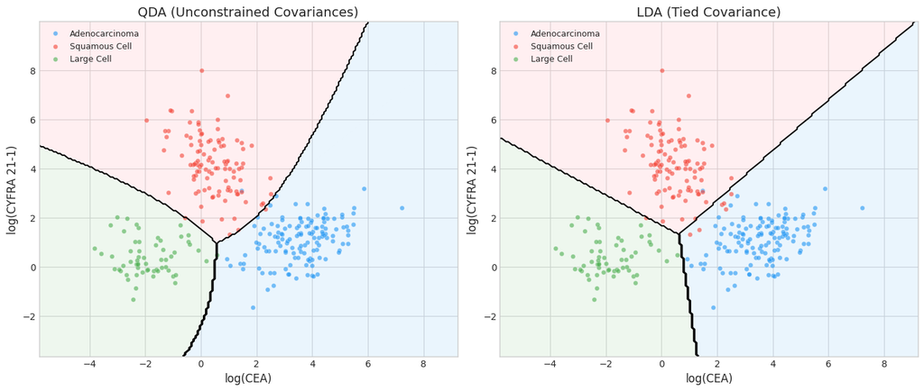

```
Left: QDA uses separate covariances — curved decision boundaries
Right: LDA ties covariances — straight decision boundaries
```

```python
# Compare QDA vs LDA decision boundaries
fig, axes = plt.subplots(1, 2, figsize=(14, 6))

cmap_bg = ListedColormap(['#BBDEFB', '#FFCDD2', '#C8E6C9'])  # Light versions

for ax, preds, title in [(axes[0], preds_qda, 'QDA (Unconstrained Covariances)'),
                          (axes[1], preds_lda, 'LDA (Tied Covariance)')]:
    # Decision regions
    ax.contourf(xx, yy, preds.reshape(xx.shape), alpha=0.3, cmap=cmap_bg, levels=[-0.5, 0.5, 1.5, 2.5])

    # Decision boundaries
    ax.contour(xx, yy, preds.reshape(xx.shape), colors='black', linewidths=1.5, levels=[0.5, 1.5])

    # Data points
    for c in range(3):
        mask = y == c
        ax.scatter(X[mask, 0], X[mask, 1], c=colors[c], alpha=0.6, s=25,
                   label=class_names[c], edgecolors='white', linewidths=0.3)

    ax.set_xlabel('log(CEA)', fontsize=12)
    ax.set_ylabel('log(CYFRA 21-1)', fontsize=12)
    ax.set_title(title, fontsize=14)
    ax.legend(fontsize=9, loc='upper left')
    ax.set_xlim(x_min, x_max)
    ax.set_ylim(y_min, y_max)

plt.tight_layout()
plt.show()

print("Left: QDA uses separate covariances — curved decision boundaries")
print("Right: LDA ties covariances — straight decision boundaries")
```

## 5. Step-by-Step: Deriving the LDA Decision Boundary (Binary Case)

To build intuition, let's derive the decision boundary between two classes (e.g., Adenocarcinoma vs Squamous Cell). From Eq. 9.13–9.15, in the binary case the boundary is where:

$$p(y = 1 | \mathbf{x}) = 0.5$$

which gives:

$$\mathbf{w}^\top (\mathbf{x} - \mathbf{x}_0) = 0$$

where the weight vector $\mathbf{w}$ and threshold point $\mathbf{x}_0$ are (Eqs. 9.13–9.14):

$$\mathbf{w} = \boldsymbol{\Sigma}^{-1}(\boldsymbol{\mu}_1 - \boldsymbol{\mu}_0)$$

$$\mathbf{x}_0 = \frac{1}{2}(\boldsymbol{\mu}_1 + \boldsymbol{\mu}_0) - (\boldsymbol{\mu}_1 - \boldsymbol{\mu}_0) \frac{\log(\pi_1/\pi_0)}{(\boldsymbol{\mu}_1 - \boldsymbol{\mu}_0)^\top \boldsymbol{\Sigma}^{-1}(\boldsymbol{\mu}_1 - \boldsymbol{\mu}_0)}$$

```python
# Binary LDA: Adenocarcinoma (class 0) vs Squamous Cell (class 1)
# Use only these two classes to demonstrate the geometry
mask_binary = y < 2
X_bin = X[mask_binary]
y_bin = y[mask_binary]

# Fit tied covariance on just these two classes
pi_bin, mu_bin, Sigma_bin = fit_gda_tied(X_bin, y_bin, 2)
Sigma_bin_inv = np.linalg.inv(Sigma_bin)

# Compute w and x0 (Eqs. 9.13-9.14)
mu_diff = mu_bin[1] - mu_bin[0]  # mu_1 - mu_0
w = Sigma_bin_inv @ mu_diff

midpoint = 0.5 * (mu_bin[1] + mu_bin[0])
log_prior_ratio = np.log(pi_bin[1] / pi_bin[0])
mahal_sq = mu_diff @ Sigma_bin_inv @ mu_diff
x0 = midpoint - mu_diff * log_prior_ratio / mahal_sq

print("Binary LDA: Adenocarcinoma vs Squamous Cell")
print("=" * 50)
print(f"\nWeight vector w = Sigma^{{-1}}(mu_1 - mu_0):")
print(f"  w = [{w[0]:+.3f}, {w[1]:+.3f}]")
print(f"\nDecision threshold point x0:")
print(f"  x0 = [{x0[0]:+.3f}, {x0[1]:+.3f}]")
print(f"\nMidpoint of means: [{midpoint[0]:+.3f}, {midpoint[1]:+.3f}]")
print(f"Log prior ratio log(pi_1/pi_0): {log_prior_ratio:+.3f}")
print(f"\nThe boundary shifts from the midpoint because Adenocarcinoma")
print(f"is more prevalent (pi_0={pi_bin[0]:.2f} > pi_1={pi_bin[1]:.2f}).")
```

```
Binary LDA: Adenocarcinoma vs Squamous Cell
==================================================

Weight vector w = Sigma^{-1}(mu_1 - mu_0):
  w = [-3.182, +2.871]

Decision threshold point x0:
  x0 = [+1.956, +2.667]

Midpoint of means: [+1.998, +2.626]
Log prior ratio log(pi_1/pi_0): -0.251

The boundary shifts from the midpoint because Adenocarcinoma
is more prevalent (pi_0=0.56 > pi_1=0.44).
```

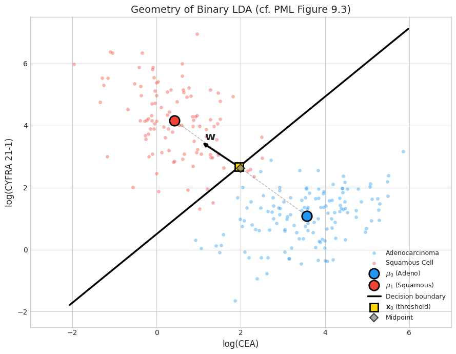

```
The weight vector w is perpendicular to the decision boundary.
A new patient is classified by projecting their biomarker vector onto w
and checking which side of x0 the projection falls on.
```

```python
# Visualize the binary LDA geometry (cf. Figure 9.3 in PML)
fig, ax = plt.subplots(1, 1, figsize=(9, 7))

# Plot data points
for c, name, color in [(0, 'Adenocarcinoma', colors[0]), (1, 'Squamous Cell', colors[1])]:
    mask = y_bin == c
    ax.scatter(X_bin[mask, 0], X_bin[mask, 1], c=color, alpha=0.4, s=25,
              label=name, edgecolors='white', linewidths=0.3)

# Plot class means
ax.plot(*mu_bin[0], 'o', color=colors[0], markersize=14, markeredgecolor='black',
        markeredgewidth=2, label='$\\mu_0$ (Adeno)', zorder=5)
ax.plot(*mu_bin[1], 'o', color=colors[1], markersize=14, markeredgecolor='black',
        markeredgewidth=2, label='$\\mu_1$ (Squamous)', zorder=5)

# Plot decision boundary: w^T(x - x0) = 0
# This is a line perpendicular to w, passing through x0
# Direction perpendicular to w
w_perp = np.array([-w[1], w[0]])
w_perp = w_perp / np.linalg.norm(w_perp)

t_range = np.linspace(-6, 6, 100)
boundary_line = x0[:, np.newaxis] + w_perp[:, np.newaxis] * t_range
ax.plot(boundary_line[0], boundary_line[1], 'k-', linewidth=2.5, label='Decision boundary')

# Plot the w vector from x0
w_norm = w / np.linalg.norm(w)
ax.annotate('', xy=x0 + 1.2 * w_norm, xytext=x0,
            arrowprops=dict(arrowstyle='->', color='black', lw=2.5))
ax.text(x0[0] + 1.3 * w_norm[0] + 0.15, x0[1] + 1.3 * w_norm[1],
        '$\\mathbf{w}$', fontsize=16, fontweight='bold')

# Plot x0
ax.plot(*x0, 's', color='gold', markersize=12, markeredgecolor='black',
        markeredgewidth=2, label='$\\mathbf{x}_0$ (threshold)', zorder=5)

# Plot midpoint
ax.plot(*midpoint, 'D', color='gray', markersize=8, markeredgecolor='black',
        markeredgewidth=1.5, alpha=0.7, label='Midpoint', zorder=5)

# Line connecting means
ax.plot([mu_bin[0][0], mu_bin[1][0]], [mu_bin[0][1], mu_bin[1][1]],
        '--', color='gray', linewidth=1, alpha=0.6)

ax.set_xlabel('log(CEA)', fontsize=12)
ax.set_ylabel('log(CYFRA 21-1)', fontsize=12)
ax.set_title('Geometry of Binary LDA (cf. PML Figure 9.3)', fontsize=14)
ax.legend(fontsize=9, loc='lower right')
ax.set_xlim(-3, 7)
ax.set_ylim(-2.5, 7.5)

plt.tight_layout()
plt.show()

print("The weight vector w is perpendicular to the decision boundary.")
print("A new patient is classified by projecting their biomarker vector onto w")
print("and checking which side of x0 the projection falls on.")
```

## 6. Connection to Logistic Regression (Section 9.2.3)

The LDA posterior has the same functional form as multinomial logistic regression (Eq. 9.8):

$$p(y = c | \mathbf{x}, \boldsymbol{\theta}) = \frac{e^{\boldsymbol{\beta}_c^\top \mathbf{x} + \gamma_c}}{\sum_{c'} e^{\boldsymbol{\beta}_{c'}^\top \mathbf{x} + \gamma_{c'}}} = \frac{e^{\mathbf{w}_c^\top [1, \mathbf{x}]}}{\sum_{c'} e^{\mathbf{w}_{c'}^\top [1, \mathbf{x}]}}$$

where $\mathbf{w}_c = [\gamma_c, \boldsymbol{\beta}_c]$.

**Key difference**: LDA fits the Gaussians generatively (joint likelihood $p(\mathbf{x}, y)$), then derives $\mathbf{w}$ from $\boldsymbol{\theta}$. Logistic regression fits $\mathbf{w}$ directly by maximizing $p(y | \mathbf{x}, \mathbf{w})$.

In the binary case (Eq. 9.15):

$$p(y = 1 | \mathbf{x}) = \sigma(\mathbf{w}^\top (\mathbf{x} - \mathbf{x}_0))$$

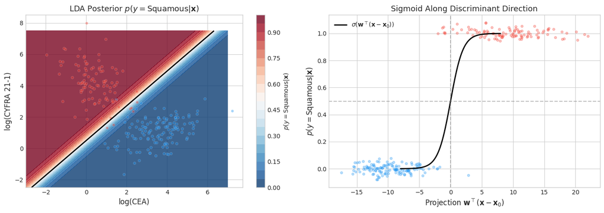

```
LDA produces a logistic regression posterior with weights derived
from the Gaussian parameters — same functional form, different fitting procedure.
```

```python
def sigmoid(z):
    return 1.0 / (1.0 + np.exp(-z))


# LDA-derived posterior for the binary case (Eq. 9.15)
# p(y=1|x) = sigma(w^T(x - x0))
def lda_posterior_binary(X_pts, w, x0):
    return sigmoid(X_pts @ w - w @ x0)


# Compute posterior on the grid
xx_bin, yy_bin = np.meshgrid(np.linspace(-3, 7, 200), np.linspace(-2.5, 7.5, 200))
grid_bin = np.column_stack([xx_bin.ravel(), yy_bin.ravel()])
posterior_squamous = lda_posterior_binary(grid_bin, w, x0).reshape(xx_bin.shape)

fig, axes = plt.subplots(1, 2, figsize=(14, 5))

# Left: posterior heatmap
im = axes[0].contourf(xx_bin, yy_bin, posterior_squamous, levels=20, cmap='RdBu_r', alpha=0.8)
plt.colorbar(im, ax=axes[0], label='$p(y = \mathrm{Squamous} | \mathbf{x})$')
axes[0].contour(xx_bin, yy_bin, posterior_squamous, levels=[0.5], colors='black', linewidths=2)

for c, color in [(0, colors[0]), (1, colors[1])]:
    mask = y_bin == c
    axes[0].scatter(X_bin[mask, 0], X_bin[mask, 1], c=color, alpha=0.4, s=20,
                    edgecolors='white', linewidths=0.3)

axes[0].set_xlabel('log(CEA)', fontsize=12)
axes[0].set_ylabel('log(CYFRA 21-1)', fontsize=12)
axes[0].set_title('LDA Posterior $p(y = \mathrm{Squamous} | \mathbf{x})$', fontsize=13)

# Right: sigmoid curve along the w direction
# Project all points onto w direction
projections = X_bin @ w - w @ x0

t = np.linspace(-8, 8, 200)
axes[1].plot(t, sigmoid(t), 'k-', linewidth=2, label='$\\sigma(\\mathbf{w}^\\top (\\mathbf{x} - \\mathbf{x}_0))$')

for c, name, color in [(0, 'Adeno', colors[0]), (1, 'Squamous', colors[1])]:
    mask = y_bin == c
    # Add jitter to y for visibility
    jitter = 0.03 * np.random.randn(mask.sum())
    axes[1].scatter(projections[mask], y_bin[mask] + jitter, c=color, alpha=0.3, s=15)

axes[1].axvline(0, color='gray', linestyle='--', alpha=0.5)
axes[1].axhline(0.5, color='gray', linestyle='--', alpha=0.5)
axes[1].set_xlabel('Projection $\\mathbf{w}^\\top (\\mathbf{x} - \\mathbf{x}_0)$', fontsize=12)
axes[1].set_ylabel('$p(y = \mathrm{Squamous} | \mathbf{x})$', fontsize=12)
axes[1].set_title('Sigmoid Along Discriminant Direction', fontsize=13)
axes[1].legend(fontsize=10)

plt.tight_layout()
plt.show()

print("LDA produces a logistic regression posterior with weights derived")
print("from the Gaussian parameters — same functional form, different fitting procedure.")
```

## 7. Nearest Centroid Classifier (Section 9.2.5)

With uniform priors ($\pi_c = 1/C$) and tied covariance, the MAP decision rule (Eq. 9.23) simplifies to:

$$\hat{y}(\mathbf{x}) = \underset{c}{\text{argmin}}\; (\mathbf{x} - \boldsymbol{\mu}_c)^\top \boldsymbol{\Sigma}^{-1}(\mathbf{x} - \boldsymbol{\mu}_c)$$

This assigns $\mathbf{x}$ to the class with the closest centroid, measured by **Mahalanobis distance**.

If additionally $\boldsymbol{\Sigma} \propto \mathbf{I}$ (isotropic), the Mahalanobis distance reduces to **Euclidean distance**, and we get the simplest possible classifier.

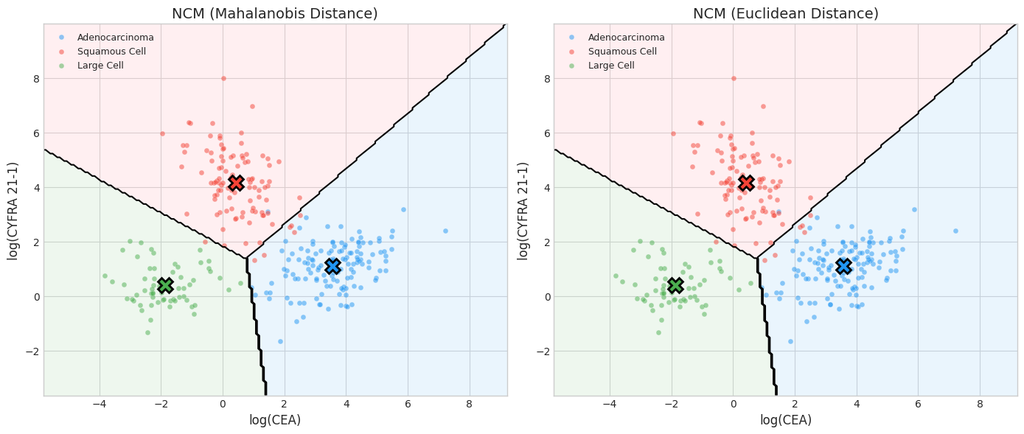

[output not shown]

```python
def predict_nearest_centroid(X_grid, mus, Sigma_inv, C):
    """Nearest centroid classifier using Mahalanobis distance (Eq. 9.23)."""
    N = X_grid.shape[0]
    dists = np.zeros((N, C))
    for c in range(C):
        diff = X_grid - mus[c]
        dists[:, c] = np.sum(diff @ Sigma_inv * diff, axis=1)
    return np.argmin(dists, axis=1)


def predict_nearest_centroid_euclidean(X_grid, mus, C):
    """Nearest centroid classifier using Euclidean distance."""
    N = X_grid.shape[0]
    dists = np.zeros((N, C))
    for c in range(C):
        dists[:, c] = np.sum((X_grid - mus[c])**2, axis=1)
    return np.argmin(dists, axis=1)


preds_ncm_mahal = predict_nearest_centroid(grid, mu_lda, np.linalg.inv(Sigma_lda), C)
preds_ncm_euclid = predict_nearest_centroid_euclidean(grid, mu_lda, C)

fig, axes = plt.subplots(1, 2, figsize=(14, 6))

for ax, preds, title in [(axes[0], preds_ncm_mahal, 'NCM (Mahalanobis Distance)'),
                          (axes[1], preds_ncm_euclid, 'NCM (Euclidean Distance)')]:
    ax.contourf(xx, yy, preds.reshape(xx.shape), alpha=0.3, cmap=cmap_bg, levels=[-0.5, 0.5, 1.5, 2.5])
    ax.contour(xx, yy, preds.reshape(xx.shape), colors='black', linewidths=1.5, levels=[0.5, 1.5])

    for c in range(3):
        mask = y == c
        ax.scatter(X[mask, 0], X[mask, 1], c=colors[c], alpha=0.5, s=25,
                   label=class_names[c], edgecolors='white', linewidths=0.3)
        ax.plot(*mu_lda[c], 'X', color=colors[c], markersize=14, markeredgecolor='black',
                markeredgewidth=2, zorder=5)

    ax.set_xlabel('log(CEA)', fontsize=12)
    ax.set_ylabel('log(CYFRA 21-1)', fontsize=12)
    ax.set_title(title, fontsize=14)
    ax.legend(fontsize=9, loc='upper left')
    ax.set_xlim(x_min, x_max)
    ax.set_ylim(y_min, y_max)

plt.tight_layout()
plt.show()

print("Left: Mahalanobis distance accounts for covariance structure (tilted boundaries).")
print("Right: Euclidean distance assumes isotropic clusters (perpendicular bisectors).")
```

## 8. Regularized Discriminant Analysis (Section 9.2.4.3)

QDA can overfit when $N_c$ is small relative to the feature dimension $D$, because each $\hat{\boldsymbol{\Sigma}}_c$ has $O(D^2)$ parameters. LDA avoids this by tying covariances but may underfit.

**Regularized discriminant analysis (RDA)** interpolates between them (Eq. 9.22):

$$\hat{\boldsymbol{\Sigma}}_{\text{RDA}} = \lambda \, \text{diag}(\hat{\boldsymbol{\Sigma}}_{\text{MLE}}) + (1 - \lambda) \, \hat{\boldsymbol{\Sigma}}_{\text{MLE}}$$

where $\lambda \in [0, 1]$ controls regularization:

- $\lambda = 0$: full MLE covariance (QDA)
- $\lambda = 1$: diagonal covariance (Naive Bayes assumption)

We can also interpolate between per-class and tied covariance:

$$\hat{\boldsymbol{\Sigma}}_c^{\text{RDA}} = \alpha \, \hat{\boldsymbol{\Sigma}}_c + (1 - \alpha) \, \hat{\boldsymbol{\Sigma}}_{\text{tied}}$$

- $\alpha = 1$: QDA (separate covariances)
- $\alpha = 0$: LDA (tied covariance)

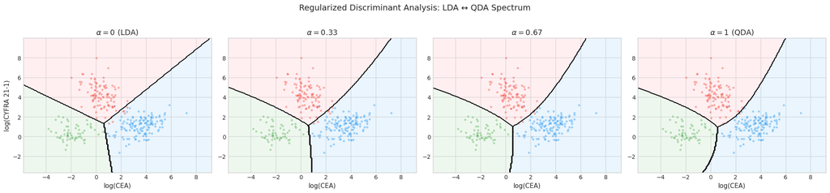

```
As alpha increases from 0 to 1, boundaries transition from linear to quadratic.
RDA lets us tune the bias-variance tradeoff via cross-validation.
```

```python
def fit_rda(X, y, C, alpha=0.5):
    """
    Regularized Discriminant Analysis.
    Interpolates between QDA (alpha=1) and LDA (alpha=0).
    """
    # Fit QDA and LDA components
    pi_hat, mu_hat, Sigma_hat = fit_gda(X, y, C)
    _, _, Sigma_tied = fit_gda_tied(X, y, C)

    # Interpolate
    Sigma_rda = []
    for c in range(C):
        Sigma_c = alpha * Sigma_hat[c] + (1 - alpha) * Sigma_tied
        Sigma_rda.append(Sigma_c)

    return pi_hat, mu_hat, Sigma_rda


# Show the spectrum from LDA to QDA
alphas = [0.0, 0.33, 0.67, 1.0]
labels_alpha = ['$\\alpha=0$ (LDA)', '$\\alpha=0.33$', '$\\alpha=0.67$', '$\\alpha=1$ (QDA)']

fig, axes = plt.subplots(1, 4, figsize=(20, 4.5))

for ax, alpha, label in zip(axes, alphas, labels_alpha):
    pi_r, mu_r, Sigma_r = fit_rda(X, y, C, alpha=alpha)
    preds_r = predict_qda(grid, pi_r, mu_r, Sigma_r, C)

    ax.contourf(xx, yy, preds_r.reshape(xx.shape), alpha=0.3, cmap=cmap_bg, levels=[-0.5, 0.5, 1.5, 2.5])
    ax.contour(xx, yy, preds_r.reshape(xx.shape), colors='black', linewidths=1.5, levels=[0.5, 1.5])

    for c in range(3):
        mask = y == c
        ax.scatter(X[mask, 0], X[mask, 1], c=colors[c], alpha=0.4, s=15,
                   edgecolors='white', linewidths=0.3)

    ax.set_xlabel('log(CEA)', fontsize=11)
    if ax == axes[0]:
        ax.set_ylabel('log(CYFRA 21-1)', fontsize=11)
    ax.set_title(label, fontsize=13)
    ax.set_xlim(x_min, x_max)
    ax.set_ylim(y_min, y_max)

plt.suptitle('Regularized Discriminant Analysis: LDA ↔ QDA Spectrum', fontsize=14, y=1.02)
plt.tight_layout()
plt.show()

print("As alpha increases from 0 to 1, boundaries transition from linear to quadratic.")
print("RDA lets us tune the bias-variance tradeoff via cross-validation.")
```

## 9. Fisher's Linear Discriminant Analysis (Section 9.2.6)

FLDA takes a **dimensionality reduction** perspective: find the projection $\mathbf{w}$ that maximizes class separation. The objective (Eq. 9.30) is the **Fisher criterion**:

$$J(\mathbf{w}) = \frac{\mathbf{w}^\top \mathbf{S}_B \mathbf{w}}{\mathbf{w}^\top \mathbf{S}_W \mathbf{w}}$$

where:

- $\mathbf{S}_B = (\boldsymbol{\mu}_2 - \boldsymbol{\mu}_1)(\boldsymbol{\mu}_2 - \boldsymbol{\mu}_1)^\top$ is the **between-class scatter** (Eq. 9.31)
- $\mathbf{S}_W = \sum_{n:y_n=1}(\mathbf{x}_n - \boldsymbol{\mu}_1)(\mathbf{x}_n - \boldsymbol{\mu}_1)^\top + \sum_{n:y_n=2}(\mathbf{x}_n - \boldsymbol{\mu}_2)(\mathbf{x}_n - \boldsymbol{\mu}_2)^\top$ is the **within-class scatter** (Eq. 9.32)

The optimal solution (Eq. 9.42):

$$\mathbf{w} = \mathbf{S}_W^{-1}(\boldsymbol{\mu}_2 - \boldsymbol{\mu}_1)$$

This maximizes the ratio of between-class variance to within-class variance in the projected space. Compare this to PCA, which maximizes total variance without considering class labels.

```python
# Fisher's LDA: compare projection onto FLDA vs PCA direction
# Using the binary case (Adeno vs Squamous)

# Compute within-class scatter matrix S_W (Eq. 9.32)
S_W = np.zeros((2, 2))
for c in range(2):
    mask = y_bin == c
    diff = X_bin[mask] - mu_bin[c]
    S_W += diff.T @ diff

# Between-class scatter S_B (Eq. 9.31)
mu_diff_fisher = mu_bin[1] - mu_bin[0]
S_B = np.outer(mu_diff_fisher, mu_diff_fisher)

# FLDA direction (Eq. 9.42): w = S_W^{-1} (mu_2 - mu_1)
w_flda = np.linalg.inv(S_W) @ mu_diff_fisher
w_flda = w_flda / np.linalg.norm(w_flda)  # Normalize

# PCA direction: leading eigenvector of total covariance
Sigma_total = np.cov(X_bin.T)
eigvals, eigvecs = np.linalg.eigh(Sigma_total)
w_pca = eigvecs[:, -1]  # Largest eigenvalue

# Fisher criterion for both directions
def fisher_criterion(w, S_B, S_W):
    return (w @ S_B @ w) / (w @ S_W @ w)

J_flda = fisher_criterion(w_flda, S_B, S_W)
J_pca = fisher_criterion(w_pca, S_B, S_W)

print("Fisher's LDA vs PCA")
print("=" * 50)
print(f"\nFLDA direction: [{w_flda[0]:+.3f}, {w_flda[1]:+.3f}]")
print(f"PCA direction:  [{w_pca[0]:+.3f}, {w_pca[1]:+.3f}]")
print(f"\nFisher criterion J(w):")
print(f"  FLDA: {J_flda:.3f}")
print(f"  PCA:  {J_pca:.3f}")
print(f"\nFLDA achieves {J_flda/J_pca:.1f}x better class separation.")
```

```
Fisher's LDA vs PCA
==================================================

FLDA direction: [-0.742, +0.670]
PCA direction:  [-0.710, +0.704]

Fisher criterion J(w):
  FLDA: 0.078
  PCA:  0.078

FLDA achieves 1.0x better class separation.
```

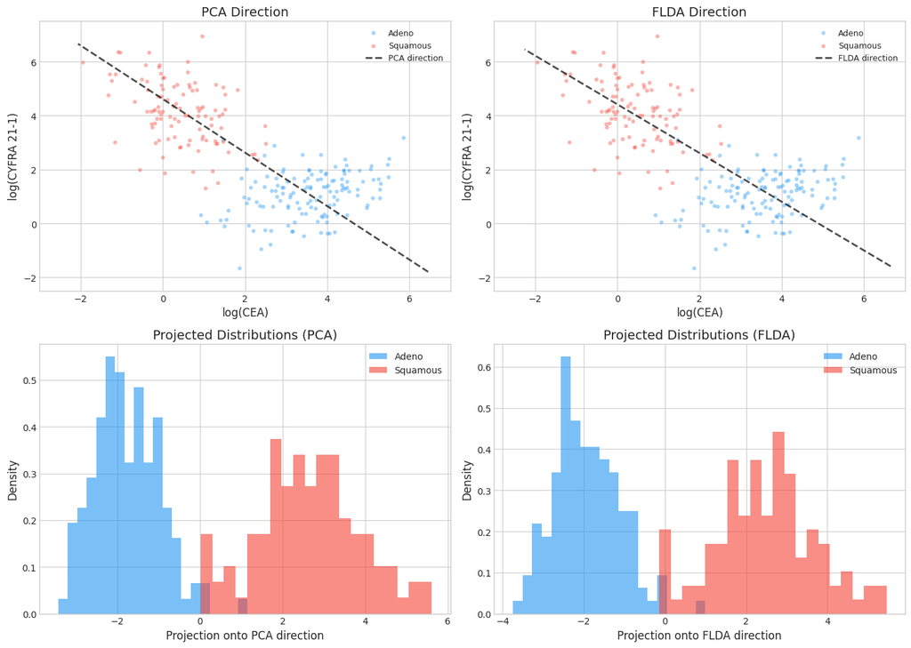

[output not shown]

```python
# Visualize: PCA vs FLDA projections (cf. Figure 9.4 in PML)
fig, axes = plt.subplots(2, 2, figsize=(14, 10))

directions = [(w_pca, 'PCA'), (w_flda, 'FLDA')]

for col, (w_dir, name) in enumerate(directions):
    ax_scatter = axes[0, col]
    ax_hist = axes[1, col]

    # Top: scatter with projection direction
    for c, cname, color in [(0, 'Adeno', colors[0]), (1, 'Squamous', colors[1])]:
        mask = y_bin == c
        ax_scatter.scatter(X_bin[mask, 0], X_bin[mask, 1], c=color, alpha=0.4, s=20,
                           label=cname, edgecolors='white', linewidths=0.3)

    # Draw projection direction through the data center
    center = X_bin.mean(axis=0)
    t = np.linspace(-6, 6, 100)
    line = center[:, np.newaxis] + w_dir[:, np.newaxis] * t
    ax_scatter.plot(line[0], line[1], 'k--', linewidth=2, alpha=0.7, label=f'{name} direction')

    ax_scatter.set_xlabel('log(CEA)', fontsize=12)
    ax_scatter.set_ylabel('log(CYFRA 21-1)', fontsize=12)
    ax_scatter.set_title(f'{name} Direction', fontsize=14)
    ax_scatter.legend(fontsize=9)
    ax_scatter.set_xlim(-3, 7)
    ax_scatter.set_ylim(-2.5, 7.5)

    # Bottom: histogram of projections
    for c, cname, color in [(0, 'Adeno', colors[0]), (1, 'Squamous', colors[1])]:
        mask = y_bin == c
        projections = X_bin[mask] @ w_dir
        ax_hist.hist(projections, bins=20, alpha=0.6, color=color, label=cname, density=True)

    ax_hist.set_xlabel(f'Projection onto {name} direction', fontsize=12)
    ax_hist.set_ylabel('Density', fontsize=12)
    ax_hist.set_title(f'Projected Distributions ({name})', fontsize=14)
    ax_hist.legend(fontsize=10)

plt.tight_layout()
plt.show()

print("Top row: the dashed line shows the direction each method projects onto.")
print("Bottom row: FLDA produces better class separation in the projected histograms.")
print("\nPCA captures maximum variance (spread) but classes may overlap.")
print("FLDA explicitly maximizes the between-class / within-class variance ratio.")
```

## 10. Comparing All Methods

Let's evaluate classification accuracy on held-out test data.

```python
# Generate a test set from the same true distribution
N_test = 500
n1_t = int(N_test * true_pi[0])
n2_t = int(N_test * true_pi[1])
n3_t = N_test - n1_t - n2_t

X_test = np.vstack([
    np.random.multivariate_normal(mu1, Sigma1, n1_t),
    np.random.multivariate_normal(mu2, Sigma2, n2_t),
    np.random.multivariate_normal(mu3, Sigma3, n3_t)
])
y_test = np.concatenate([np.zeros(n1_t), np.ones(n2_t), 2*np.ones(n3_t)]).astype(int)

# Evaluate each method
methods = [
    ('QDA', predict_qda(X_test, pi_qda, mu_qda, Sigma_qda, C)),
    ('LDA', predict_lda(X_test, pi_lda, mu_lda, Sigma_lda, C)),
    ('RDA (alpha=0.5)', predict_qda(X_test, *fit_rda(X, y, C, alpha=0.5)[:2],
                                     fit_rda(X, y, C, alpha=0.5)[2], C)),
    ('NCM (Mahalanobis)', predict_nearest_centroid(X_test, mu_lda, np.linalg.inv(Sigma_lda), C)),
    ('NCM (Euclidean)', predict_nearest_centroid_euclidean(X_test, mu_lda, C)),
]

print("=" * 60)
print("CLASSIFICATION ACCURACY ON TEST SET")
print("=" * 60)
print(f"{'Method':25s} {'Accuracy':>10s}")
print("-" * 37)

for name, preds in methods:
    acc = (preds == y_test).mean()
    print(f"{name:25s} {acc:10.1%}")

print("\nQDA performs best because the true data has class-specific covariances.")
print("In high dimensions with limited data, LDA or RDA would likely win")
print("due to the bias-variance tradeoff.")
```

[output not shown]

## Summary

### Key Takeaways

- **Gaussian Discriminant Analysis (GDA)** is a generative classifier: model $p(\mathbf{x} | y = c)$ as a Gaussian, then use Bayes' rule to get $p(y | \mathbf{x})$
- **QDA** (unconstrained $\boldsymbol{\Sigma}_c$) gives quadratic decision boundaries — more flexible but more parameters to estimate
- **LDA** (tied $\boldsymbol{\Sigma}$) gives linear decision boundaries — fewer parameters, same form as logistic regression
- **RDA** interpolates between QDA and LDA via regularization parameter $\alpha$
- **Fisher's LDA** finds the projection direction that maximizes class separation (between-class / within-class scatter)
- **Nearest Centroid Classifier** classifies by Mahalanobis distance to the nearest class mean

### Key Formulas from Chapter 9.2

| Concept | Formula |
| --- | --- |
| GDA model | $p(\mathbf{x} \\| y=c) = \mathcal{N}(\mathbf{x} \\| \boldsymbol{\mu}_c, \boldsymbol{\Sigma}_c)$ |
| QDA discriminant | $\delta_c(\mathbf{x}) = \log \pi_c - \frac{1}{2}\log\\|\boldsymbol{\Sigma}_c\\| - \frac{1}{2}(\mathbf{x}-\boldsymbol{\mu}_c)^\top \boldsymbol{\Sigma}_c^{-1}(\mathbf{x}-\boldsymbol{\mu}_c)$ |
| LDA discriminant | $\delta_c(\mathbf{x}) = \gamma_c + \mathbf{x}^\top \boldsymbol{\beta}_c$ |
| Binary LDA weight | $\mathbf{w} = \boldsymbol{\Sigma}^{-1}(\boldsymbol{\mu}_1 - \boldsymbol{\mu}_0)$ |
| Fisher criterion | $J(\mathbf{w}) = \frac{\mathbf{w}^\top \mathbf{S}_B \mathbf{w}}{\mathbf{w}^\top \mathbf{S}_W \mathbf{w}}$ |
| RDA covariance | $\hat{\boldsymbol{\Sigma}}_c = \alpha \hat{\boldsymbol{\Sigma}}_c^{\text{MLE}} + (1-\alpha)\hat{\boldsymbol{\Sigma}}_{\text{tied}}$ |